# Using Mixscale to analyze Perturb-seq data

Longda Jiang

2024-01-16

## Introduction

In this tutorial, we will describe an R package “Mixscale” for analyzing Perturb-seq data. Mixscale contains functions designed to tackle the following tasks:  
1. calculate ‘Mixscale scores’ for cells that receives the same perturbation to quantify the heterogeneity in perturbation strength  
2. perform a scoring-based weighted differential expression (DE) tests to identify DE genes for each perturbation  
3. perform different levels of decomposition analysis to identify correlated perturbations and group them into a program  
4. perform a PCA-based permutation test to extract shared genes for the perturbation programs (program gene signature)  
5. identify shared and unique signature between two relevant programs  
6. perform gene set enrichment tests using the program signature for new datasets  
7. perform module score analyses using the program signature to quantify the program activity in new datasets  
The tutorial is divided into two sections. The first section will describe task 1 to 5 using a public Perturb-seq dataset from the Weissman Lab ([Jost et al 2020](https://www.nature.com/articles/s41587-019-0387-5)), which can be downloaded from GSE132080. The second section will describe task 6 and 7 using the pathway gene lists generated from our study (available at Zenodo) and an interferon-beta stimulated human PBMCs dataset (ifnb) from [Kang et al 2017](https://www.nature.com/articles/nbt.4042). This ifnb dataset is available via the SeuratData package (see section 2 below).

### install the Mixscale package

The package can be easily installed using the following command. Please make sure the dependencies like [Seurat](https://satijalab.org/seurat/) are installed prior to this.

```r
# dependencies
install.packages("Seurat")
install.packages("PMA")
install.packages("protoclust")
BiocManager::install("glmGamPoi")

# Mixscale package
devtools::install_github("longmanz/Mixscale")
```

### load the packages

```r
options(Seurat.object.assay.version = 'v3')

library(Seurat)
library(ggridges)
library(ggplot2)
library(Mixscale)
```

## Section A.

In this section we will focus on how to use Mixscale to analyze Perturb-seq data.

### 0. Description of the demo data

The demo dataset from [Jost et al 2020](https://www.nature.com/articles/s41587-019-0387-5) contains CRISPRi Perturb-seq data targeting 25 key genes involved in essential cell biological processes. We will load in the count matrix to create a Seurat object and append the provided meta data to it.  
One special feature of this dataset is that, for each perturbation target gene, there are five different gRNAs designed to target it. One of the gRNA has the perfectly matched sequence for the target region (labelled with “_00”), while the others contain 1~3 nucleotide mismatches so that their perturbation stength is “titrated”. We will treat the cells that have the same target gene as the same group in our downstream analyses.

**Click here to see how to generate the Seurat object**

```r
library(stringr)

# load in the count matrix downloaded from GSE132080
ct_mat = ReadMtx(mtx = "GSE132080/GSE132080_10X_matrix.mtx",
                 cells = "GSE132080/GSE132080_10X_barcodes.tsv",
                 features = "GSE132080/GSE132080_10X_genes.tsv")
# load the meta_data
meta_data = read.csv("GSE132080/GSE132080_cell_identities.csv")
rownames(meta_data) = meta_data$cell_barcode

# create a seurat object
seurat_obj = CreateSeuratObject(counts = ct_mat, meta.data = meta_data)
rm(ct_mat, meta_data)

# retrieve the guide information for each cell
txt = seurat_obj$guide_identity
txt2 = str_extract(txt, "^[^_]+")
txt3 = gsub(pattern = "^[^_]+_", replacement = "", txt)
seurat_obj[['gene']] = txt2
seurat_obj[['gRNA_name']] = txt3
seurat_obj[['cell_type']] = "K562"
rm(txt, txt2, txt3)

# remove ambiguous cells
seurat_obj = subset(seurat_obj, subset = number_of_cells == 1)  # 19594 cells remain
seurat_obj = subset(seurat_obj, subset = guide_identity != '*')  # 19587 cells remain
```

### 1. Pre-processing and calculating the Mixscale score

We will first run standard pre-processing (normalization, find variable features, etc) for the dataset. Then, we will follow the standard [Mixscape analysis](https://satijalab.org/seurat/articles/mixscape_vignette) to calculate local perturbation signatures that mitigate confounding effects. Briefly speaking, for each cell we will search for its 20 nearest neighbors from the non-targeted (NT) cells, and then remove all technical variation so that perturbation-specific effect can be revealed.

```r
# quick check of the data
seurat_obj
```

```
## An object of class Seurat
## 33694 features across 19587 samples within 1 assay
## Active assay: RNA (33694 features, 0 variable features)
##  2 layers present: counts, data
```

```r
# standard pre-processing
seurat_obj = NormalizeData(seurat_obj)
seurat_obj = FindVariableFeatures(seurat_obj)
seurat_obj = ScaleData(seurat_obj)
seurat_obj = RunPCA(seurat_obj)

# calculate Perturbation signatures
seurat_obj <- CalcPerturbSig(
    object = seurat_obj,
    assay = "RNA",
    slot = "data",
    gd.class ="gene",
    nt.cell.class = "neg",
    reduction = "pca",
    ndims = 40,
    num.neighbors = 20,
    new.assay.name = "PRTB")
```

We will now compute the Mixscale scores for each cell in every perturbation group. The standardized Mixscale scores will be saved in the metadata under the column named “mixscale_score”.

```r
# Mixscale
seurat_obj = RunMixscale(
    object = seurat_obj,
    assay = "PRTB",
    slot = "scale.data",
    labels = "gene",
    nt.class.name = "neg",
    min.de.genes = 5,
    logfc.threshold = 0.2,
    de.assay = "RNA",
    max.de.genes = 100,
    new.class.name = "mixscale_score", fine.mode = F, verbose = F)
```

```
## [1] "Running Mixscale scoring to calculate the perturbation scores \n"
## [1] "con1"
```

```r
# quickly check the scores
summary(seurat_obj$mixscale_score)
```

```
##    Min. 1st Qu.  Median    Mean 3rd Qu.    Max.
## -3.9082  0.4617  2.3980  3.6635  5.1837 41.7821
```

### 2. Visualizations for the scores

We will now use some plotting functions to explore the perturbation scores that we just calculated.

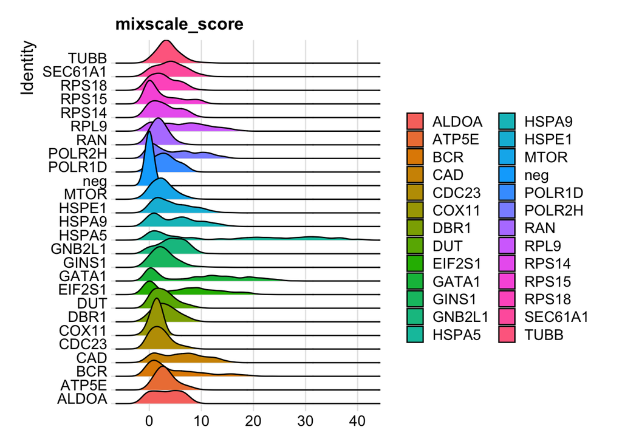

```r
# a. Check the distribution of the scores for the perturbations
RidgePlot(
    seurat_obj,
    features = "mixscale_score",
    group.by = "gene")
```

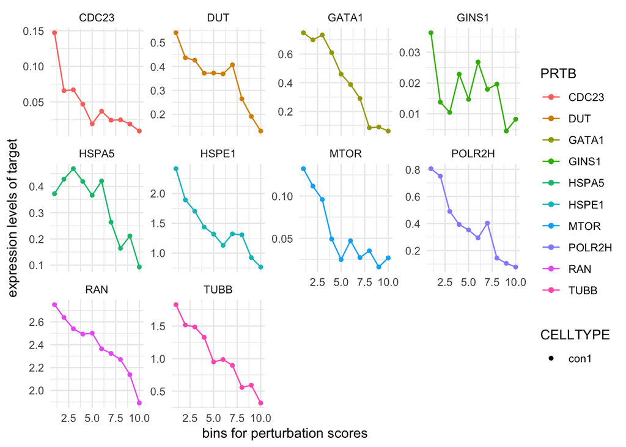

```r
# b. Check if the scores correlate with the expression level of the target gene itself
Mixscale_ScatterPlot(object = seurat_obj, nt.class.name = "neg",
                     PRTB = unique(seurat_obj$gene)[unique(seurat_obj$gene) != "neg"][1:10],
                      facet_wrap = "gene", facet_scale = "free_y", nbin = 10)
```